# Limpieza y análisis de datos del Titanic

Autores: Saúl Santomé Rúa y Víctor Elías Afonso Rodríguez

Mayo 2021

```r
# Cargamos los paquetes R que vamos a usar
library(ggplot2)
library(dplyr)

# Cargamos el fichero de datos
titanicData <- read.csv('titanicData.csv',stringsAsFactors = FALSE)
filas=dim(titanicData)[1]
columnas=dim(titanicData)[2]

# Verificamos la estructura del conjunto de datos
str(titanicData)
```

```
## 'data.frame':    891 obs. of  12 variables:
##  $ PassengerId: int  1 2 3 4 5 6 7 8 9 10 ...
##  $ Survived   : int  0 1 1 1 0 0 0 0 1 1 ...
##  $ Pclass     : int  3 1 3 1 3 3 1 3 3 2 ...
##  $ Name       : chr  "Braund, Mr. Owen Harris" "Cumings, Mrs. John Bradley (Florence Briggs Thayer)" "Heikkinen, Miss. Laina" "Futrelle, Mrs. Jacques Heath (Lily May Peel)" ...
##  $ Sex        : chr  "male" "female" "female" "female" ...
##  $ Age        : num  22 38 26 35 35 NA 54 2 27 14 ...
##  $ SibSp      : int  1 1 0 1 0 0 0 3 0 1 ...
##  $ Parch      : int  0 0 0 0 0 0 0 1 2 0 ...
##  $ Ticket     : chr  "A/5 21171" "PC 17599" "STON/O2. 3101282" "113803" ...
##  $ Fare       : num  7.25 71.28 7.92 53.1 8.05 ...
##  $ Cabin      : chr  "" "C85" "" "C123" ...
##  $ Embarked   : chr  "S" "C" "S" "S" ...
```

Se muestra un resumen

```r
summary(titanicData)
```

```
##   PassengerId       Survived          Pclass          Name
##  Min.   :  1.0   Min.   :0.0000   Min.   :1.000   Length:891
##  1st Qu.:223.5   1st Qu.:0.0000   1st Qu.:2.000   Class :character
##  Median :446.0   Median :0.0000   Median :3.000   Mode  :character
##  Mean   :446.0   Mean   :0.3838   Mean   :2.309
##  3rd Qu.:668.5   3rd Qu.:1.0000   3rd Qu.:3.000
##  Max.   :891.0   Max.   :1.0000   Max.   :3.000
##
##      Sex                 Age            SibSp           Parch
##  Length:891         Min.   : 0.42   Min.   :0.000   Min.   :0.0000
##  Class :character   1st Qu.:20.12   1st Qu.:0.000   1st Qu.:0.0000
##  Mode  :character   Median :28.00   Median :0.000   Median :0.0000
##                     Mean   :29.70   Mean   :0.523   Mean   :0.3816
##                     3rd Qu.:38.00   3rd Qu.:1.000   3rd Qu.:0.0000
##                     Max.   :80.00   Max.   :8.000   Max.   :6.0000
##                     NA's   :177
##     Ticket               Fare           Cabin             Embarked
##  Length:891         Min.   :  0.00   Length:891         Length:891
##  Class :character   1st Qu.:  7.91   Class :character   Class :character
##  Mode  :character   Median : 14.45   Mode  :character   Mode  :character
##                     Mean   : 32.20
##                     3rd Qu.: 31.00
##                     Max.   :512.33
##
```

Esta guay mostrar los valores unicos, para ver si hay alguno extraño. Aqui se añade texto explicando si se encuentra algun valor raro, lo interesante es hacerlo solo con las variables discretas(hay que filtrar el for para que solo se haga con las discretas). Spoiler ->, no hay ningun valor raro. Esto deberia ir antes de la eliminacion de valores nulos, ya que al ver los uniques es como sabemos que los nulos se representan con ""

```r
for (i in 1:dim(titanicData)[2]){
    print(unique(titanicData[i]))
}
```

[output not shown]

[output cut: 2970 more lines]

Se muestran los datos vacios

```r
# Estadísticas de valores vacíos
colSums(is.na(titanicData))
```

```
## PassengerId    Survived      Pclass        Name         Sex         Age
##           0           0           0           0           0         177
##       SibSp       Parch      Ticket        Fare       Cabin    Embarked
##           0           0           0           0           0           0
```

```r
colSums(titanicData=="")
```

```
## PassengerId    Survived      Pclass        Name         Sex         Age
##           0           0           0           0           0          NA
##       SibSp       Parch      Ticket        Fare       Cabin    Embarked
##           0           0           0           0         687           2
```

— Age: Como vemos aqui hay muchos pasajeros que no tienen edad, habria que buscar solucion (aplicar algoritmo, probablemente la mediana o la media, quizas borrar)

— Cabin: en cabin hay muchisimos vacios, se podría intentar identificar el por que… van menos de un dia y no duermen, no pagaron camarote, son personal del barco y no tienen asignado camarote, etc. hay que ver como solventar que esta variable este vacia. aqui lo mejor creo que es ponerle un “desconocido” ya que cualquier otro valor daria resultados erroneos en el analisis, y borrarlos es exagerado ya que hay muchisimos

— Embarked: aquí solo hay 2 valores vacios, seria una buena opcion borrarlos y olvidarse de ellos, pero hay que valorarlo.

```r
# Ponemos la media a los valores vacíos de la variable "Age"
titanicData$Age[is.na(titanicData$Age)] <- mean(titanicData$Age,na.rm=T)

# Ponemos valor "Desconocido" a los valores vacíos de la variable "Cabin"
titanicData$Cabin[titanicData$Cabin==""]="Desconocido"

#Borramos los valores vacios de embarked
titanicData <- titanicData[!titanicData$Embarked=="",]

head(titanicData)
```

```
##   PassengerId Survived Pclass
## 1           1        0      3
## 2           2        1      1
## 3           3        1      3
## 4           4        1      1
## 5           5        0      3
## 6           6        0      3
##                                                  Name    Sex      Age SibSp
## 1                             Braund, Mr. Owen Harris   male 22.00000     1
## 2 Cumings, Mrs. John Bradley (Florence Briggs Thayer) female 38.00000     1
## 3                              Heikkinen, Miss. Laina female 26.00000     0
## 4        Futrelle, Mrs. Jacques Heath (Lily May Peel) female 35.00000     1
## 5                            Allen, Mr. William Henry   male 35.00000     0
## 6                                    Moran, Mr. James   male 29.69912     0
##   Parch           Ticket    Fare       Cabin Embarked
## 1     0        A/5 21171  7.2500 Desconocido        S
## 2     0         PC 17599 71.2833         C85        C
## 3     0 STON/O2. 3101282  7.9250 Desconocido        S
## 4     0           113803 53.1000        C123        S
## 5     0           373450  8.0500 Desconocido        S
## 6     0           330877  8.4583 Desconocido        Q
```

Ahora vamos a discretizar la variable edad, que nos resultará útil a la hora de analizar…..

```r
# Añadimos la edad discretizada al dataset. Discretizamos con intervalos de igual amplitud

summary(titanicData[,"Age"])
```

```
##    Min. 1st Qu.  Median    Mean 3rd Qu.    Max.
##    0.42   22.00   29.70   29.65   35.00   80.00
```

```r
titanicData["Age_discreta"] <- cut(titanicData$Age, breaks = c(0,10,20,30,40,50,60,70,81), labels = c("0-9", "10-19", "20-29", "30-39","40-49","50-59","60-69","70-80"))

head(titanicData)
```

```
##   PassengerId Survived Pclass
## 1           1        0      3
## 2           2        1      1
## 3           3        1      3
## 4           4        1      1
## 5           5        0      3
## 6           6        0      3
##                                                  Name    Sex      Age SibSp
## 1                             Braund, Mr. Owen Harris   male 22.00000     1
## 2 Cumings, Mrs. John Bradley (Florence Briggs Thayer) female 38.00000     1
## 3                              Heikkinen, Miss. Laina female 26.00000     0
## 4        Futrelle, Mrs. Jacques Heath (Lily May Peel) female 35.00000     1
## 5                            Allen, Mr. William Henry   male 35.00000     0
## 6                                    Moran, Mr. James   male 29.69912     0
##   Parch           Ticket    Fare       Cabin Embarked Age_discreta
## 1     0        A/5 21171  7.2500 Desconocido        S        20-29
## 2     0         PC 17599 71.2833         C85        C        30-39
## 3     0 STON/O2. 3101282  7.9250 Desconocido        S        20-29
## 4     0           113803 53.1000        C123        S        30-39
## 5     0           373450  8.0500 Desconocido        S        30-39
## 6     0           330877  8.4583 Desconocido        Q        20-29
```

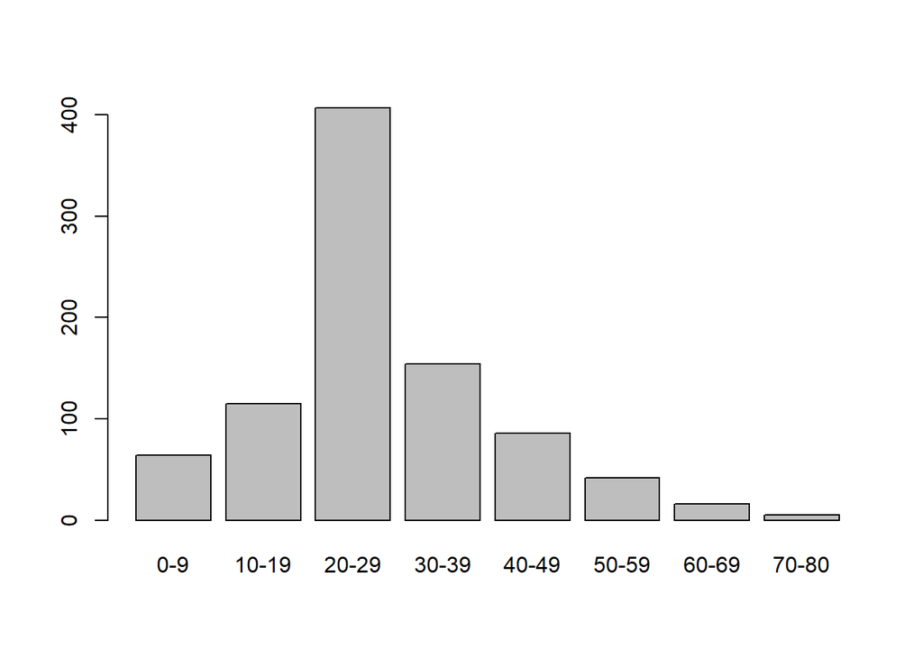

```r
plot(titanicData$Age_discreta)
```

Tambien se podría normalizar un dato, para “demostrar” que sabemos hacerlo jajaja. pero bueno, tampoco es muy necesario, aunque es muy sencillo, por ejemplo.

```r
#Normalizacion por la diferencia
minFare = min(titanicData$Fare)
maxFare = max(titanicData$Fare)
diffMinMaxFare = maxFare - minFare

titanicData["Fare_norm"] <- ((titanicData$Fare - minFare) / diffMinMaxFare)
head(titanicData)
```

```
##   PassengerId Survived Pclass
## 1           1        0      3
## 2           2        1      1
## 3           3        1      3
## 4           4        1      1
## 5           5        0      3
## 6           6        0      3
##                                                  Name    Sex      Age SibSp
## 1                             Braund, Mr. Owen Harris   male 22.00000     1
## 2 Cumings, Mrs. John Bradley (Florence Briggs Thayer) female 38.00000     1
## 3                              Heikkinen, Miss. Laina female 26.00000     0
## 4        Futrelle, Mrs. Jacques Heath (Lily May Peel) female 35.00000     1
## 5                            Allen, Mr. William Henry   male 35.00000     0
## 6                                    Moran, Mr. James   male 29.69912     0
##   Parch           Ticket    Fare       Cabin Embarked Age_discreta  Fare_norm
## 1     0        A/5 21171  7.2500 Desconocido        S        20-29 0.01415106
## 2     0         PC 17599 71.2833         C85        C        30-39 0.13913574
## 3     0 STON/O2. 3101282  7.9250 Desconocido        S        20-29 0.01546857
## 4     0           113803 53.1000        C123        S        30-39 0.10364430
## 5     0           373450  8.0500 Desconocido        S        30-39 0.01571255
## 6     0           330877  8.4583 Desconocido        Q        20-29 0.01650950
```

Simplificacion de datos: Ahora vamos a analizar los valores redundantes, o que simplemente no tengan una funcion especial en el dataset, como por ejemplo, el nombre de los pasajeros no es nada util teniendo un id de pasajero, asi que podriamos simplemente eliminar esa columna.

se puede tambien hacer alguna comparacion entre si 2 campos coinciden mucho, pero ya se ve a suimple vista que no, asi que no seria muy necesario

Ahora se podrian ver valores extremos. por ejemplo el precio, que hay un billete que valio mas de 500 € como vimos en el summary

aqui podemos aprovechar nuestra variable normalizada o no, tanto da

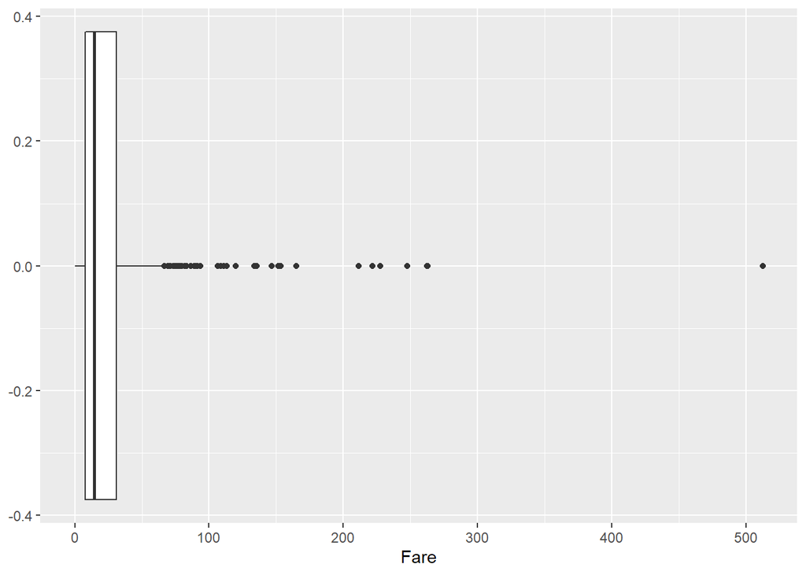

```r
#representación de la distribución de los precios de los billetes
ggplot(data=titanicData, aes(x=Fare)) + geom_boxplot()
```

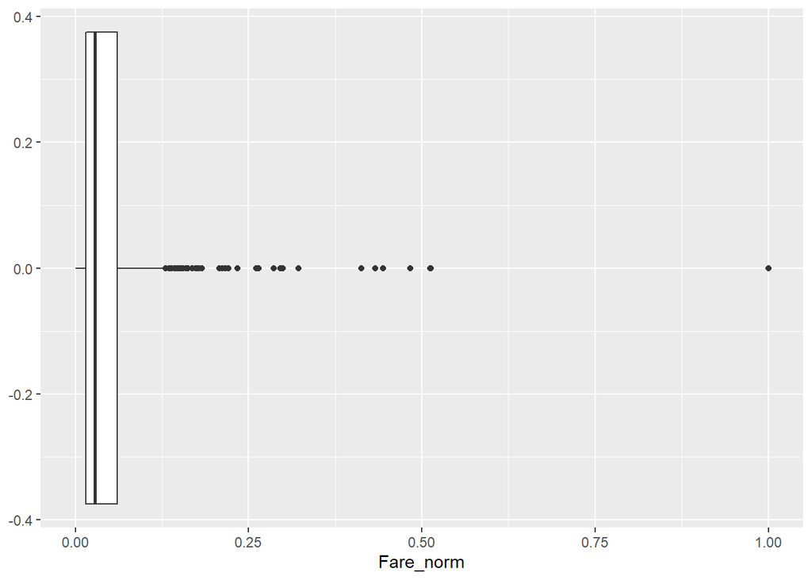

```r
ggplot(data=titanicData, aes(x=Fare_norm)) + geom_boxplot()
```

Vemos como el valor de 500 es altamente extraño, podriamos buscarle solucion, o eliminarlo, tambien hay valores por encima de 200 que chirrian un poco, pero aqui ya se podria ver si coinciden con camarotes de lujo etc.

Creo que no hay mas variables donde ver valores extremos.

## Analisis

Como la varaible survived es una clase vamos a discretizar la varaible tranformandola a string

```r
titanicData["Survived_discreta"] <- cut(titanicData$Survived, breaks = c(-1,0.5,1), labels = c("No", "Si"))

head(titanicData)
```

```
##   PassengerId Survived Pclass
## 1           1        0      3
## 2           2        1      1
## 3           3        1      3
## 4           4        1      1
## 5           5        0      3
## 6           6        0      3
##                                                  Name    Sex      Age SibSp
## 1                             Braund, Mr. Owen Harris   male 22.00000     1
## 2 Cumings, Mrs. John Bradley (Florence Briggs Thayer) female 38.00000     1
## 3                              Heikkinen, Miss. Laina female 26.00000     0
## 4        Futrelle, Mrs. Jacques Heath (Lily May Peel) female 35.00000     1
## 5                            Allen, Mr. William Henry   male 35.00000     0
## 6                                    Moran, Mr. James   male 29.69912     0
##   Parch           Ticket    Fare       Cabin Embarked Age_discreta  Fare_norm
## 1     0        A/5 21171  7.2500 Desconocido        S        20-29 0.01415106
## 2     0         PC 17599 71.2833         C85        C        30-39 0.13913574
## 3     0 STON/O2. 3101282  7.9250 Desconocido        S        20-29 0.01546857
## 4     0           113803 53.1000        C123        S        30-39 0.10364430
## 5     0           373450  8.0500 Desconocido        S        30-39 0.01571255
## 6     0           330877  8.4583 Desconocido        Q        20-29 0.01650950
##   Survived_discreta
## 1                No
## 2                Si
## 3                Si
## 4                Si
## 5                No
## 6                No
```

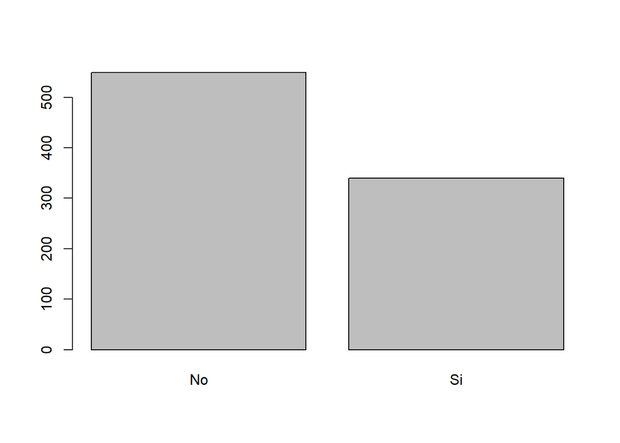

```r
plot(titanicData$Survived_discreta)
```

Esto se puede usar como introducción y para tener una idea visual de como afectan las diferentes variables en la supervivencia y asi elegir que datos analizar. Antes de hacerlo de la homogeniedad y normalidad, y aplicar las correlaciones, regrasiones, etc.

A partir de aqui ya comenzariamos con el analisis de los datos, asi que hay que empezar a comparar los diferentes atributos con la varaible survived

Empezamos por la edad

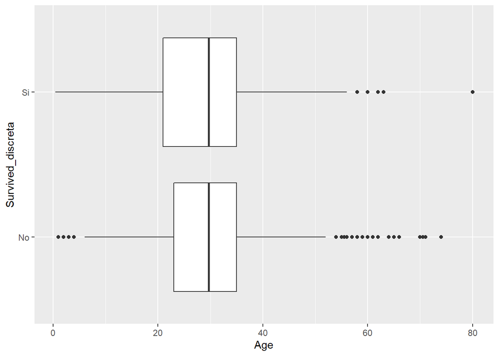

```r
ggplot(data=titanicData, aes(x=Age, y=Survived_discreta)) + geom_boxplot()
```

Sex

No se por que coño sale NA aqui, hay que arreglarlo, pero no encuentro el por que

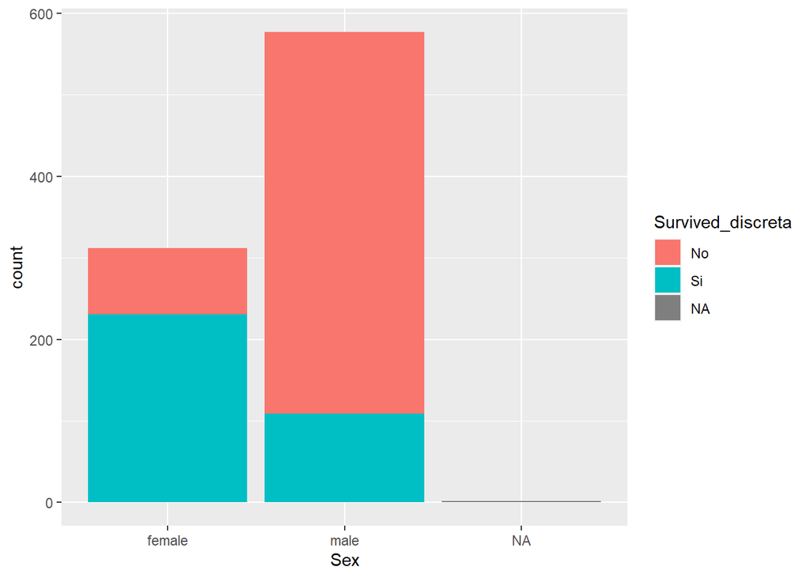

```r
ggplot(data=titanicData[1:filas,],aes(x=Sex,fill=Survived_discreta))+geom_bar()
```

Relacion entre age y sex para ampliar explicacion sobre losd atos de antes

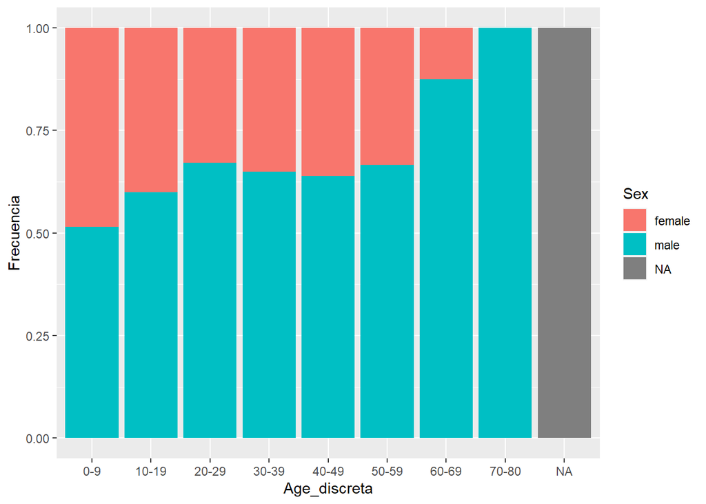

```r
ggplot(data=titanicData[1:filas,],aes(x=Age_discreta,fill=Sex))+geom_bar(position="fill")+ylab("Frecuencia")
```

Ahora hay que seguir buscando relaciones interesantes para completar el analisis

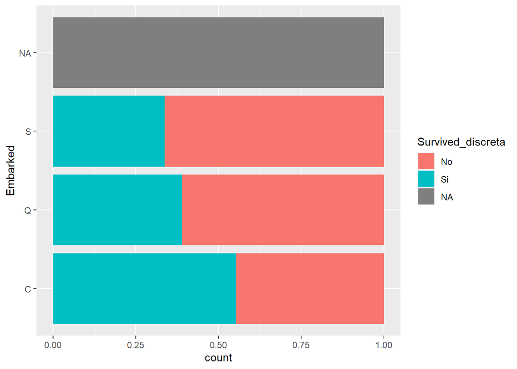

```r
ggplot(data=titanicData[1:filas,],aes(y=Embarked,fill=Survived_discreta))+geom_bar(position="fill")
```

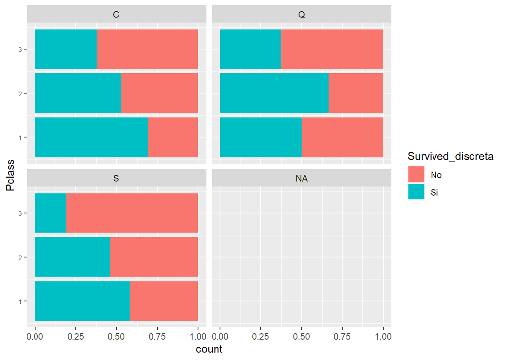

```r
ggplot(data=titanicData[1:filas,],aes(y=Pclass,fill=Survived_discreta))+geom_bar(position="fill")+facet_wrap(~Embarked)+theme(axis.text.y = element_text(size = rel(0.7)))
```

Y a partir de aqui todas las combinaciones de columnas y graficas de las que podamos sacar algo de partido para explicar bien el analisis